# Landsat 8 y 9: búsqueda y descarga completa

## Nubosidad

`eo:cloud_cover` es el porcentaje de nubes de **toda la escena**, no del polígono. L1 y L2 de una misma adquisición pueden tener igual nubosidad.

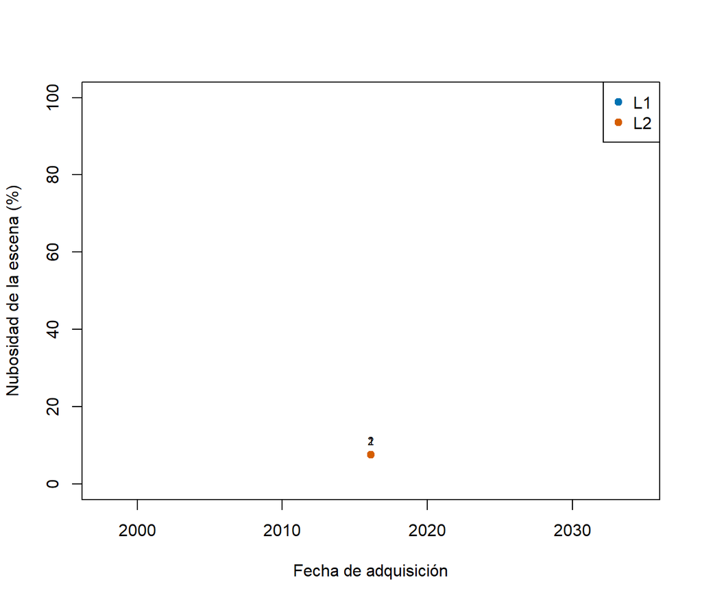

```r
validas <- !is.na(tabla$nubes_pct)
if (any(validas)) {
  colores <- ifelse(tabla$nivel == "L1", "#0072B2", "#D55E00")
  plot(as.Date(tabla$fecha[validas]), tabla$nubes_pct[validas],
       col = colores[validas], pch = 19, ylim = c(0, 100),
       xlab = "Fecha de adquisición", ylab = "Nubosidad de la escena (%)")
  text(as.Date(tabla$fecha[validas]), tabla$nubes_pct[validas],
       labels = which(validas), pos = 3, cex = 0.7)
  legend("topright", c("L1", "L2"), col = c("#0072B2", "#D55E00"), pch = 19)
} else {
  cat("Las escenas no informan nubosidad válida.")
}
```

Los números sobre los puntos corresponden a las filas de la tabla y del CSV. Algunos puntos pueden superponerse.

## Descargar los productos elegidos

STAC separa reflectancia (`SR`) y temperatura (`ST`) en nivel 2. Aquí se descarga el **Product Bundle** de USGS: incluye todos los archivos del producto L1 o L2, sin limitarse a las bandas de una colección STAC. En L2SR no hay temperatura superficial; L2SP incluye los archivos de temperatura disponibles.

```
Descargado: LC08_L1TP_232083_20160209_20200907_02_T1 — 24 entradas del paquete.
```

## Referencias

- [Catálogo STAC de USGS](https://www.usgs.gov/landsat-missions/spatiotemporal-asset-catalog-stac).
- [rstac: búsqueda](https://brazil-data-cube.github.io/rstac/reference/stac_search.html).
- [USGS: paquetes completos y bandas](https://www.usgs.gov/software/machine-machine-m2m-landsat-download-bands-bundles-and-band-groups).
- [Solicitar acceso M2M](https://www.usgs.gov/faqs/how-can-i-bulk-download-usgs-earth-resources-observation-and-science-eros-products).
- [Crear un token de aplicación](https://www.usgs.gov/media/files/m2m-application-token-documentation).